# Classification

Jeu de données res.PCA

.

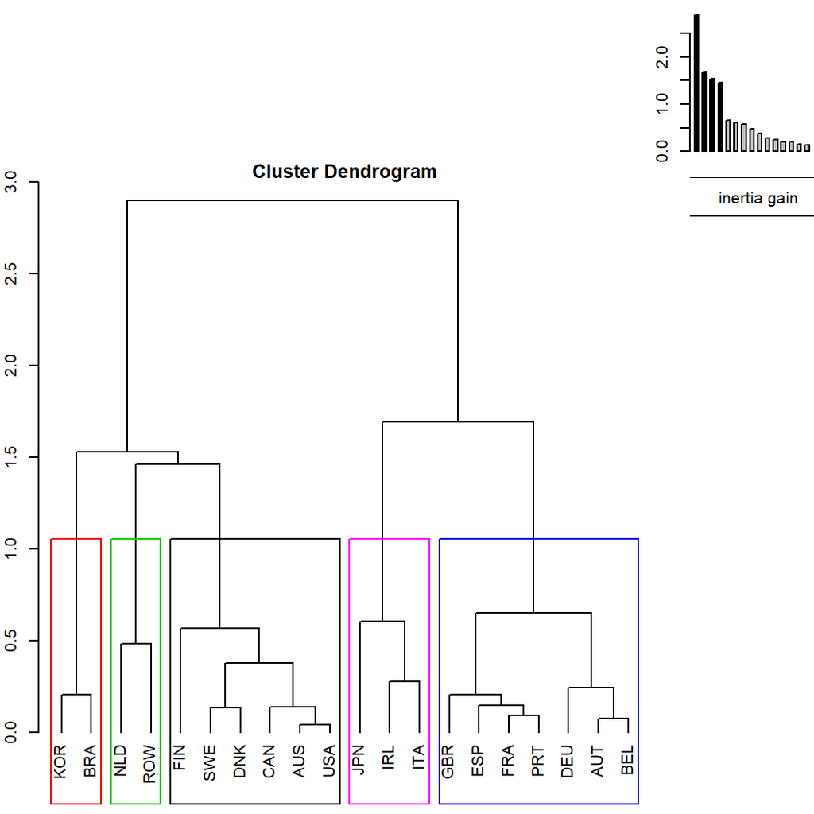

**Figure 1.1 - Arbre hiérarchique.**

La classification réalisée sur les individus fait apparaître 5 classes.

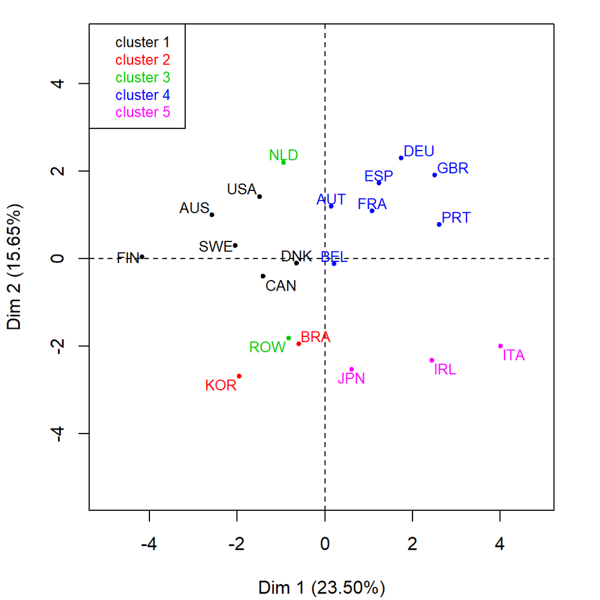

**Figure 1.2 - Classification Ascendante Hiérachique des individus.**

La **classe 1** est composée d’individus tels que *AUS*, *FIN* et *SWE*. Ce groupe est caractérisé par :

- de fortes valeurs pour les variables *AZ_Fwd* et *C1_Fwd* (de la plus extrême à la moins extrême).
- de faibles valeurs pour les variables *C3_Bwd*, *KZ_Fwd*, *GZ_Fwd* et *MN_Fwd* (de la plus extrême à la moins extrême).

La **classe 2** est composée d’individus tels que *BRA* et *KOR*. Ce groupe est caractérisé par :

- de fortes valeurs pour la variable *C2_Fwd*.
- de faibles valeurs pour les variables *RU_Fwd*, *C4_Fwd* et *FZ_Fwd* (de la plus extrême à la moins extrême).

La **classe 3** est composée d’individus tels que *NLD* et *ROW*. Ce groupe est caractérisé par :

- de faibles valeurs pour les variables *AZ_Fwd* et *HZ_Fwd* (de la plus extrême à la moins extrême).

La **classe 4** est composée d’individus tels que *DEU*, *ESP*, *GBR* et *PRT*. Ce groupe est caractérisé par :

- de fortes valeurs pour les variables *C4_Bwd*, *C3_Fwd* et *HZ_Fwd* (de la plus extrême à la moins extrême).
- de faibles valeurs pour les variables *IZ_Fwd*, *C2_Fwd*, *RU_Bwd* et *IZ_Bwd* (de la plus extrême à la moins extrême).

La **classe 5** est composée d’individus tels que *IRL*, *ITA* et *JPN*. Ce groupe est caractérisé par :

- de fortes valeurs pour les variables *KZ_Fwd*, *JZ_Bwd*, *JZ_Fwd* et *DE_Bwd* (de la plus extrême à la moins extrême).
- de faibles valeurs pour les variables *C4_Bwd*, *C5_Fwd* et *C5_Bwd* (de la plus extrême à la moins extrême).

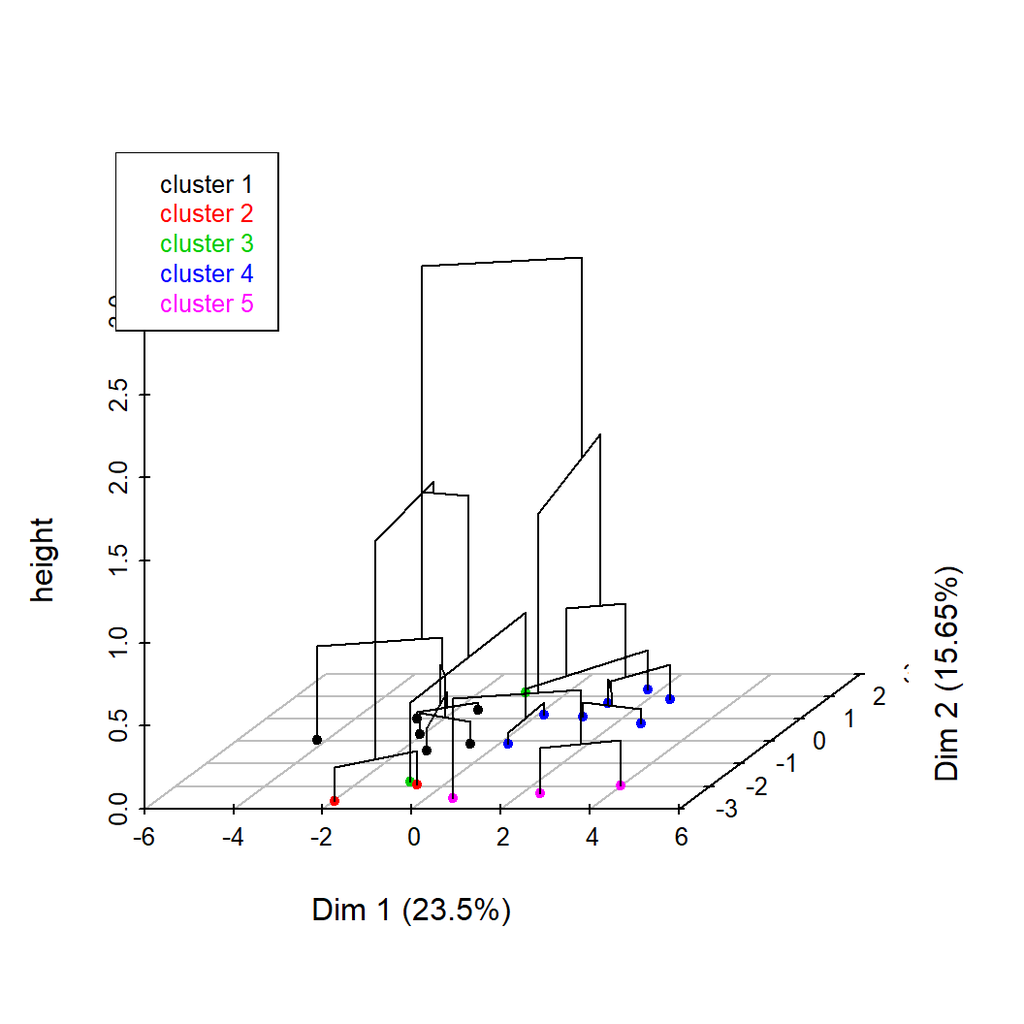

**Figure 1.3 - Arbre hiérarchique sur le plan factoriel.**

The hierarchical tree can be drawn on the factorial map with the individuals colored according to their clusters.